# NYPD Shooting incidents

Domenico Guadalupi

2024-04-11

## The background

In the bustling metropolis of New York City, safety is a paramount concern. Over the past year, the city has witnessed an alarming number of shooting incidents. But is NYC a safe place to call home? Which neighborhoods pose the greatest risks? And are we seeing any improvements over time?

In this analysis, we delve deep into the data provided by the NYPD to unravel the truths behind the statistics.

## Understanding the data

We begin by examining “The NYPD Shooting Incident Data (Historic)” dataset, which contains detailed records of shooting incidents across the city:

```r
url_shoot <- 'https://data.cityofnewyork.us/api/views/833y-fsy8/rows.csv'
data <- read_csv(url_shoot)
head(data)
```

```
## # A tibble: 6 × 21
##   INCIDENT_KEY OCCUR_DATE OCCUR_TIME BORO     LOC_OF_OCCUR_DESC PRECINCT
##          <dbl> <chr>      <time>     <chr>    <chr>                <dbl>
## 1    228798151 05/27/2021 21:30      QUEENS   <NA>                   105
## 2    137471050 06/27/2014 17:40      BRONX    <NA>                    40
## 3    147998800 11/21/2015 03:56      QUEENS   <NA>                   108
## 4    146837977 10/09/2015 18:30      BRONX    <NA>                    44
## 5     58921844 02/19/2009 22:58      BRONX    <NA>                    47
## 6    219559682 10/21/2020 21:36      BROOKLYN <NA>                    81
## # ℹ 15 more variables: JURISDICTION_CODE <dbl>, LOC_CLASSFCTN_DESC <chr>,
## #   LOCATION_DESC <chr>, STATISTICAL_MURDER_FLAG <lgl>, PERP_AGE_GROUP <chr>,
## #   PERP_SEX <chr>, PERP_RACE <chr>, VIC_AGE_GROUP <chr>, VIC_SEX <chr>,
## #   VIC_RACE <chr>, X_COORD_CD <dbl>, Y_COORD_CD <dbl>, Latitude <dbl>,
## #   Longitude <dbl>, Lon_Lat <chr>
```

Let’s start by familiarizing ourselves with the dataset. It contains comprehensive records of shooting incidents, capturing crucial details such as incident key, date, time, location, and demographics of both perpetrators and victims.

```r
fields_matrix <- matrix(c('INCIDENT_KEY', 'Randomly generated persistent ID for each incident',
'OCCUR_DATE', 'Date of the shooting incident',
'OCCUR_TIME', 'Time of the shooting incident',
'BORO', 'Borough where the shooting incident occurred',
'PRECINCT', 'Precinct where the shooting incident occurred',
'JURISDICTION_CODE', 'Jurisdiction where the shooting incident occurred.Jurisdiction codes 0(Patrol), 1(Transit) and 2(Housing) represent NYPD whilst codes 3 and more represent non NYPD jurisdictions',
'LOCATION_DESC', 'Location of the shooting incident',
'STATISTICAL_MURDER_FLAG', 'Shooting resulted in the victim’s death which would be counted as a murder',
'PERP_AGE_GROUP', 'Perpetrator’s age within a category',
'PERP_SEX', 'Perpetrator’s sex description',
'PERP_RACE', 'Perpetrator’s race description',
'VIC_AGE_GROUP', 'Victim’s age within a category',
'VIC_SEX', 'Victim’s sex description',
'VIC_RACE', 'Victim’s race description',
'X_COORD_CD', 'Midblock X-coordinate for New York State Plane Coordinate System, Long Island Zone, NAD 83, units feet (FIPS 3104)',
'Y_COORD_CD', 'Midblock Y-coordinate for New York State Plane Coordinate System, Long Island Zone, NAD 83, units feet (FIPS 3104)',
'Latitude', 'Latitude coordinate for Global Coordinate System, WGS 1984, decimal degrees (EPSG 4326)',
'Longitude', 'Longitude coordinate for Global Coordinate System, WGS 1984, decimal degrees (EPSG 4326)'

), ncol=2, byrow=TRUE, dimnames = list(NULL, c('field', 'description')))
fields <- as.data.frame(fields_matrix)
knitr::kable(fields)
```

| field | description |
| --- | --- |
| INCIDENT_KEY | Randomly generated persistent ID for each incident |
| OCCUR_DATE | Date of the shooting incident |
| OCCUR_TIME | Time of the shooting incident |
| BORO | Borough where the shooting incident occurred |
| PRECINCT | Precinct where the shooting incident occurred |
| JURISDICTION_CODE | Jurisdiction where the shooting incident occurred.Jurisdiction codes 0(Patrol), 1(Transit) and 2(Housing) represent NYPD whilst codes 3 and more represent non NYPD jurisdictions |
| LOCATION_DESC | Location of the shooting incident |
| STATISTICAL_MURDER_FLAG | Shooting resulted in the victim’s death which would be counted as a murder |
| PERP_AGE_GROUP | Perpetrator’s age within a category |
| PERP_SEX | Perpetrator’s sex description |
| PERP_RACE | Perpetrator’s race description |
| VIC_AGE_GROUP | Victim’s age within a category |
| VIC_SEX | Victim’s sex description |
| VIC_RACE | Victim’s race description |
| X_COORD_CD | Midblock X-coordinate for New York State Plane Coordinate System, Long Island Zone, NAD 83, units feet (FIPS 3104) |
| Y_COORD_CD | Midblock Y-coordinate for New York State Plane Coordinate System, Long Island Zone, NAD 83, units feet (FIPS 3104) |
| Latitude | Latitude coordinate for Global Coordinate System, WGS 1984, decimal degrees (EPSG 4326) |
| Longitude | Longitude coordinate for Global Coordinate System, WGS 1984, decimal degrees (EPSG 4326) |

```r
summary(data)
```

```
##   INCIDENT_KEY        OCCUR_DATE         OCCUR_TIME           BORO
##  Min.   :  9953245   Length:27312       Length:27312      Length:27312
##  1st Qu.: 63860880   Class :character   Class1:hms        Class :character
##  Median : 90372218   Mode  :character   Class2:difftime   Mode  :character
##  Mean   :120860536                      Mode  :numeric
##  3rd Qu.:188810230
##  Max.   :261190187
##
##  LOC_OF_OCCUR_DESC     PRECINCT      JURISDICTION_CODE LOC_CLASSFCTN_DESC
##  Length:27312       Min.   :  1.00   Min.   :0.0000    Length:27312
##  Class :character   1st Qu.: 44.00   1st Qu.:0.0000    Class :character
##  Mode  :character   Median : 68.00   Median :0.0000    Mode  :character
##                     Mean   : 65.64   Mean   :0.3269
##                     3rd Qu.: 81.00   3rd Qu.:0.0000
##                     Max.   :123.00   Max.   :2.0000
##                                      NA's   :2
##  LOCATION_DESC      STATISTICAL_MURDER_FLAG PERP_AGE_GROUP
##  Length:27312       Mode :logical           Length:27312
##  Class :character   FALSE:22046             Class :character
##  Mode  :character   TRUE :5266              Mode  :character
##
##
##
##
##    PERP_SEX          PERP_RACE         VIC_AGE_GROUP        VIC_SEX
##  Length:27312       Length:27312       Length:27312       Length:27312
##  Class :character   Class :character   Class :character   Class :character
##  Mode  :character   Mode  :character   Mode  :character   Mode  :character
##
##
##
##
##    VIC_RACE           X_COORD_CD        Y_COORD_CD        Latitude
##  Length:27312       Min.   : 914928   Min.   :125757   Min.   :40.51
##  Class :character   1st Qu.:1000029   1st Qu.:182834   1st Qu.:40.67
##  Mode  :character   Median :1007731   Median :194487   Median :40.70
##                     Mean   :1009449   Mean   :208127   Mean   :40.74
##                     3rd Qu.:1016838   3rd Qu.:239518   3rd Qu.:40.82
##                     Max.   :1066815   Max.   :271128   Max.   :40.91
##                                                        NA's   :10
##    Longitude        Lon_Lat
##  Min.   :-74.25   Length:27312
##  1st Qu.:-73.94   Class :character
##  Median :-73.92   Mode  :character
##  Mean   :-73.91
##  3rd Qu.:-73.88
##  Max.   :-73.70
##  NA's   :10
```

We then streamline the dataset by focusing on essential fields and perform necessary transformations for analysis.

```r
data <- data[, -c(1,5:16)]

data <- data %>% mutate(OCCUR_DATE=mdy(OCCUR_DATE),
                        month=as.integer(month(OCCUR_DATE)),
                        year=as.integer(year(OCCUR_DATE))) %>%
  dplyr::select(-OCCUR_DATE)

data <- data %>% mutate(hour=hour(OCCUR_TIME)) %>% dplyr::select(-OCCUR_TIME)

data$BORO <- as.factor(data$BORO)
```

Longitude and Latitude have 10 NAs. Let’s have a look at them.

```r
data %>% filter(is.na(Longitude)|is.na(Latitude))
```

```
## # A tibble: 10 × 9
##    BORO      X_COORD_CD Y_COORD_CD Latitude Longitude Lon_Lat month  year  hour
##    <fct>          <dbl>      <dbl>    <dbl>     <dbl> <chr>   <int> <int> <int>
##  1 BROOKLYN      998002     196692       NA        NA <NA>        9  2022    22
##  2 BROOKLYN      990784     149362       NA        NA <NA>       12  2022    23
##  3 MANHATTAN    1002173     249401       NA        NA <NA>        9  2022     3
##  4 QUEENS       1019164     210169       NA        NA <NA>       11  2022     1
##  5 BROOKLYN      995122     155693       NA        NA <NA>       10  2022    19
##  6 MANHATTAN     997407     233806       NA        NA <NA>        9  2022    23
##  7 MANHATTAN     997407     233806       NA        NA <NA>        9  2022    23
##  8 MANHATTAN    1001891     245600       NA        NA <NA>       12  2022    10
##  9 QUEENS       1041717     197008       NA        NA <NA>        9  2022     1
## 10 BROOKLYN      988902     192641       NA        NA <NA>        8  2022     0
```

Latitude, Longitude, and Lon_Lat fields contain missing values for ten rows in the dataset. However, the projected coordinates fields (X_COORD_CD, Y_COORD_CD) have complete data with no missing values. To assess if these points are outliers, we visualize them on a scatter plot. Red points represent the rows with missing latitude or longitude values.

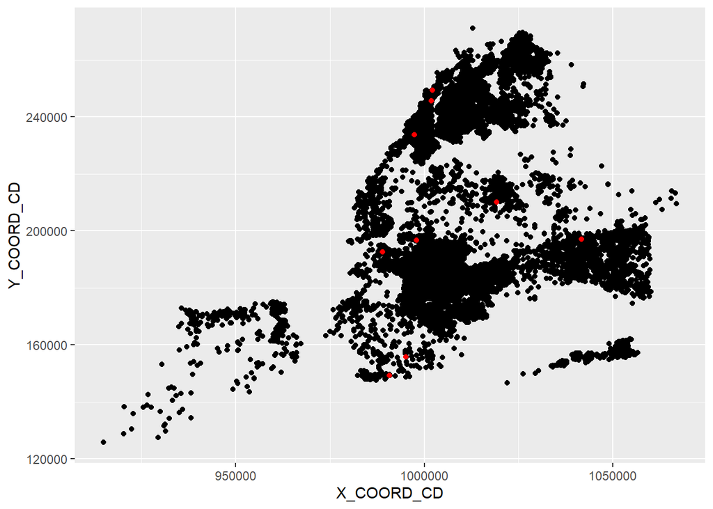

```r
ggplot(data, aes(X_COORD_CD, Y_COORD_CD))+
  geom_point()+
  geom_point(data=filter(data, is.na(Latitude)), col='red')
```

Based on the plot, there are no apparent outliers among the points with missing latitude or longitude values. Therefore, we will retain these points in the study. Subsequently, we will discard the Latitude, Longitude, and Lon_Lat columns and utilize the projected coordinates instead. The coordinate reference system employed is the New York State Plane Coordinate System, Long Island Zone, NAD 83, with units in feet (FIPS 3104), corresponding to EPSG:2263. We will use the sf library to associate a geometry and the correct reference system with the data.

```r
data <- data %>% dplyr::select(-c(Longitude, Latitude, Lon_Lat)) %>% st_as_sf(coords = c('X_COORD_CD', 'Y_COORD_CD'), crs='EPSG:2263', remove=FALSE)
head(data)
```

```
## Simple feature collection with 6 features and 6 fields
## Geometry type: POINT
## Dimension:     XY
## Bounding box:  xmin: 1004234 ymin: 180924 xmax: 1058925 ymax: 262189.4
## Projected CRS: NAD83 / New York Long Island (ftUS)
## # A tibble: 6 × 7
##   BORO     X_COORD_CD Y_COORD_CD month  year  hour                 geometry
##   <fct>         <dbl>      <dbl> <int> <int> <int> <POINT [US_survey_foot]>
## 1 QUEENS     1058925     180924      5  2021    21         (1058925 180924)
## 2 BRONX      1005028     234516      6  2014    17         (1005028 234516)
## 3 QUEENS     1007668.    209837.    11  2015     3       (1007668 209836.5)
## 4 BRONX      1006537.    244511.    10  2015    18       (1006537 244511.1)
## 5 BRONX      1024922.    262189.     2  2009    22       (1024922 262189.4)
## 6 BROOKLYN   1004234.    186462.    10  2020    21       (1004234 186461.7)
```

## Spatial Analysis: Mapping Incidents Across Boroughs

To visualize the spatial distribution of shooting incidents, we leverage the geographic data of New York City boroughs. By plotting incident locations against borough boundaries, we gain insights into the concentration of incidents in different areas. Still from the “https://data.gov/” site we download the “Borough Boundaries” dataset.

```r
url_boro <- 'https://data.cityofnewyork.us/api/views/7t3b-ywvw/rows.csv'
boro <- read_csv(url_boro)
head(boro)
```

```
## # A tibble: 5 × 5
##   the_geom                               BoroCode BoroName Shape_Leng Shape_Area
##   <chr>                                     <dbl> <chr>         <dbl>      <dbl>
## 1 MULTIPOLYGON (((-74.05050806403247 40…        5 Staten …    325917.     1.62e9
## 2 MULTIPOLYGON (((-74.01092841268026 40…        1 Manhatt…    357713.     6.37e8
## 3 MULTIPOLYGON (((-73.89680883223778 40…        2 Bronx       463181.     1.19e9
## 4 MULTIPOLYGON (((-73.86327471071958 40…        3 Brooklyn    728147.     1.93e9
## 5 MULTIPOLYGON (((-73.82644661516991 40…        4 Queens      888200.     3.04e9
```

The coordinates in the the_geom column are in WGS84 Latitude and Longitude format. To align them with the rest of our data, we project them to EPSG:2263. Additionally, we convert the Shape_Area column, which is measured in square feet (ft^2), to square kilometers (km^2), and rename it accordingly.

Furthermore, we convert the BORO field to a factor and order it to ensure consistency of colors in subsequent graphs.

```r
boro <- boro %>% mutate(geom=st_as_sfc(the_geom)) %>% st_as_sf(crs='EPSG:4326') %>% st_transform(st_crs(data)) %>% mutate(BORO = as.factor(toupper(BoroName))) %>% mutate(Area_kmq = set_units(as_units(Shape_Area,'ft^2'), 'km^2')) %>% dplyr::select(-c(1:5))

#levels(boro$BORO)=c("QUEENS", "BRONX", "BROOKLYN", "MANHATTAN", "STATEN ISLAND")

head(boro)
```

```
## Simple feature collection with 5 features and 2 fields
## Geometry type: MULTIPOLYGON
## Dimension:     XY
## Bounding box:  xmin: 913175.1 ymin: 120128.4 xmax: 1067383 ymax: 272844.3
## Projected CRS: NAD83 / New York Long Island (ftUS)
## # A tibble: 5 × 3
##                                                              geom BORO  Area_kmq
##                                   <MULTIPOLYGON [US_survey_foot]> <fct>   [km^2]
## 1 (((970217 145643.3, 970227.2 145641.6, 970273.9 145641.6, 9703… STAT…    151.
## 2 (((981219.1 188655.3, 980940.5 188435.4, 980873 188511, 981444… MANH…     59.1
## 3 (((1012822 229228.3, 1012786 229165.3, 1012704 229195.9, 10125… BRONX    110.
## 4 (((1022227 152028.1, 1022078 151928.5, 1021889 151932.2, 10217… BROO…    180.
## 5 (((1032452 154469.2, 1032458 154457.4, 1032462 154444.6, 10324… QUEE…    283.
```

We can visualize the geographic distribution of the incidents and identify the most high-risk areas by generating a scatterplot and a 2D density estimate of the distribution.

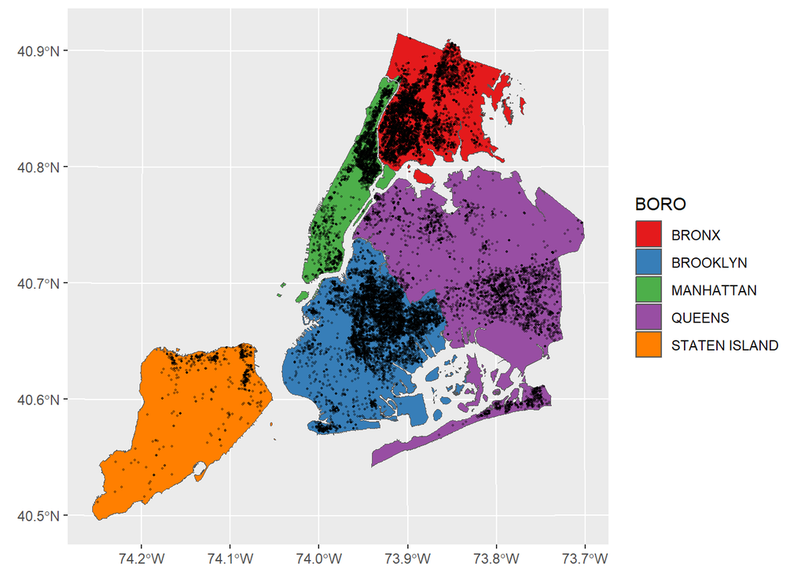

```r
ggplot()+
  geom_sf(data=boro, alpha=1, aes(fill=BORO))+scale_fill_brewer(palette='Set1')+
  geom_sf(data=data, size=0.3, alpha=0.3)
```

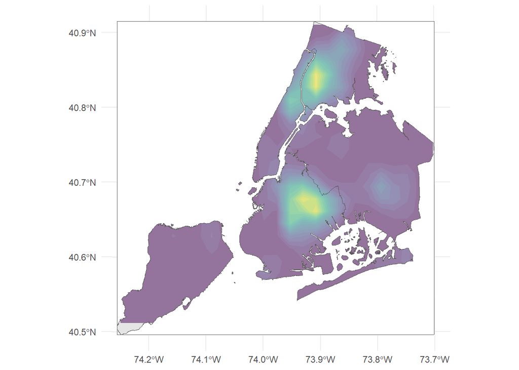

```r
density <- kde2d(data$X_COORD_CD, data$Y_COORD_CD)
df <- expand.grid(x=density$x, y=density$y)
df$density <- as.vector(density$z) %>% as.numeric()
df <- st_as_sf(df, coords = c('x', 'y'), crs='EPSG:2263', remove=FALSE)

mask <- st_difference(st_as_sfc(st_bbox(st_union(boro))), st_union(boro))

ggplot() +
  geom_sf(data=boro %>% st_transform(st_crs(data)))+
  geom_contour_filled(data=df,aes(x = x, y = y, z=density), alpha=0.5, linewidth=0.8, bins=20)+
  geom_sf(data = mask, fill='white')+
  theme_minimal()+
  theme(legend.position = 'none')+
  labs(x=NULL, y=NULL)
```

Now, let’s delve deeper into the data to identify the boroughs with the highest incidence of incidents. While there may be a common perception that the Bronx is the most dangerous area in NYC, we need to scrutinize this assumption. Is it grounded in reality, or is it merely a bias perpetuated by Hollywood films?

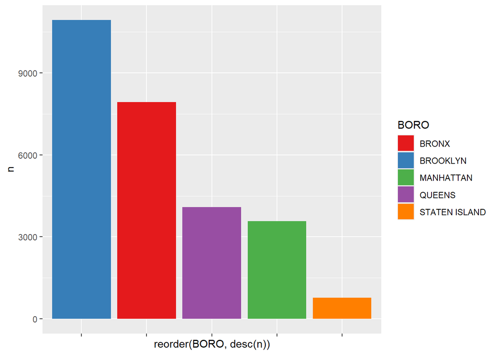

```r
ggplot(data %>% count(BORO)) +
  geom_col(aes(x=reorder(BORO,desc(n)), fill=BORO, y=n))+
  scale_fill_brewer(palette='Set1')+
  theme(axis.text.x = element_blank())
```

Upon reviewing the total counts, it appears that Brooklyn has the highest number of incidents. To make a fair comparison, we can normalize these numbers relative to the borough areas. This allows us to compare them based on the number of occurrences per square kilometer, which provides a more accurate measure of the level of danger.

```r
data <- data %>% st_drop_geometry()
boro <- boro %>% st_drop_geometry()

data <- data %>% left_join(boro)
distribution <- data %>% group_by(BORO, Area_kmq) %>% summarise(N = n()) %>% mutate(density = N/as.numeric(Area_kmq))
```

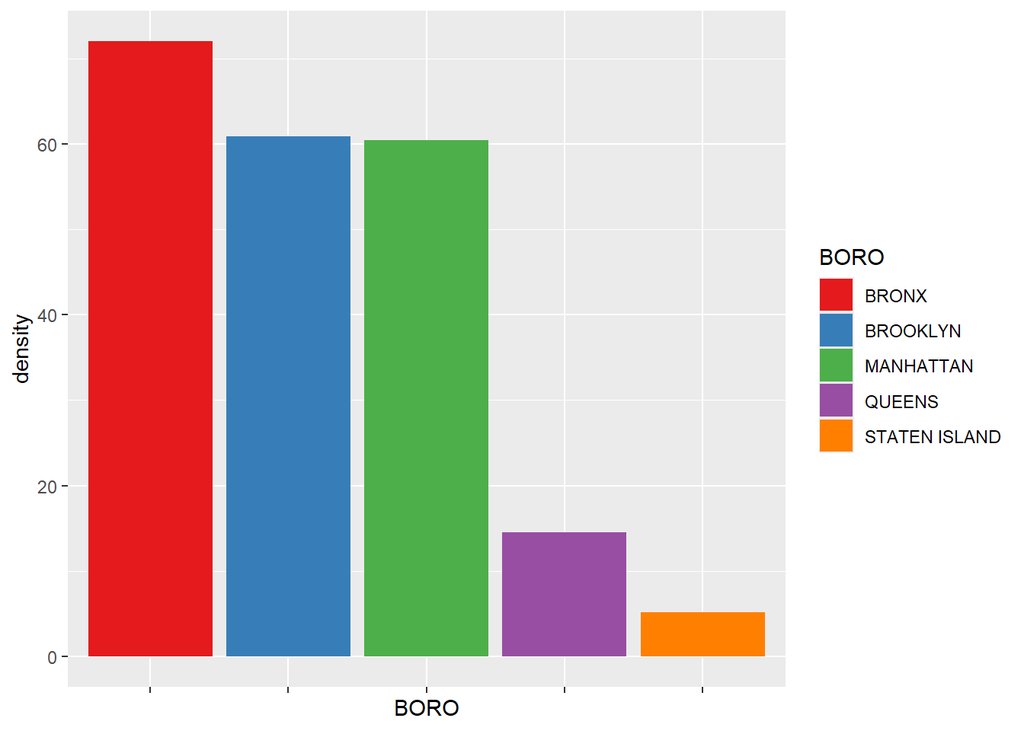

```r
ggplot(distribution) +
  geom_col(aes(x=BORO, fill=BORO, y=density))+
  scale_fill_brewer(palette='Set1')+
  theme(axis.text.x = element_blank())
```

We observe significant shifts from our earlier findings. While the Bronx indeed exhibits the highest density of incidents, both Brooklyn and Manhattan now appear remarkably similar in terms of incident density.

## Temporal Trends: Analyzing Incidents Over Time

Next, we explore how shooting incidents have evolved over the years. By analyzing citywide trends and borough-specific variations, we aim to uncover patterns and changes in incident frequency.

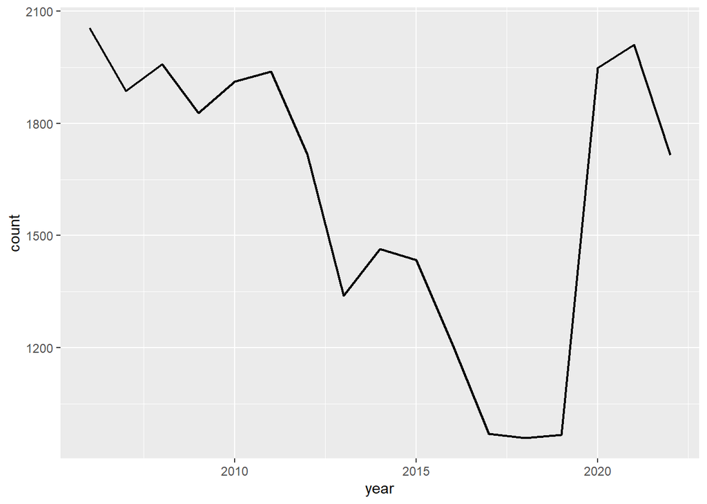

```r
ggplot(data)+
  geom_line(aes(x=year), stat='count',  linewidth=0.8)
```

We can examine the trend for each borough individually.

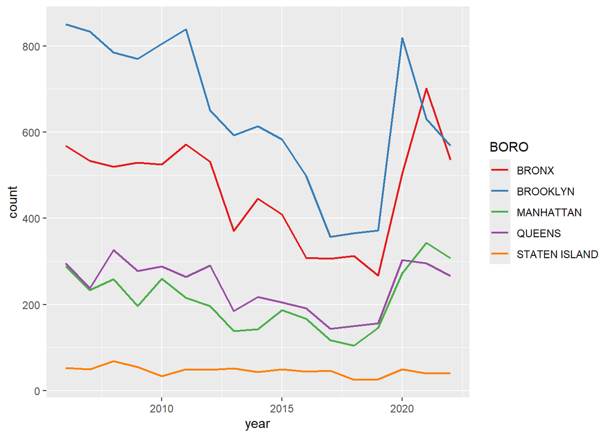

```r
ggplot(data) +
  geom_line(aes(x =year, color=BORO), stat='count', size=0.8)+
  scale_color_brewer(palette='Set1')
```

Once more, we can compare the level of danger by normalizing the data according to the area of each borough.

```r
distribution <- data %>% mutate(year) %>% group_by(BORO, Area_kmq, year) %>% summarise(N = n()) %>% mutate(freq = N/as.numeric(Area_kmq))
```

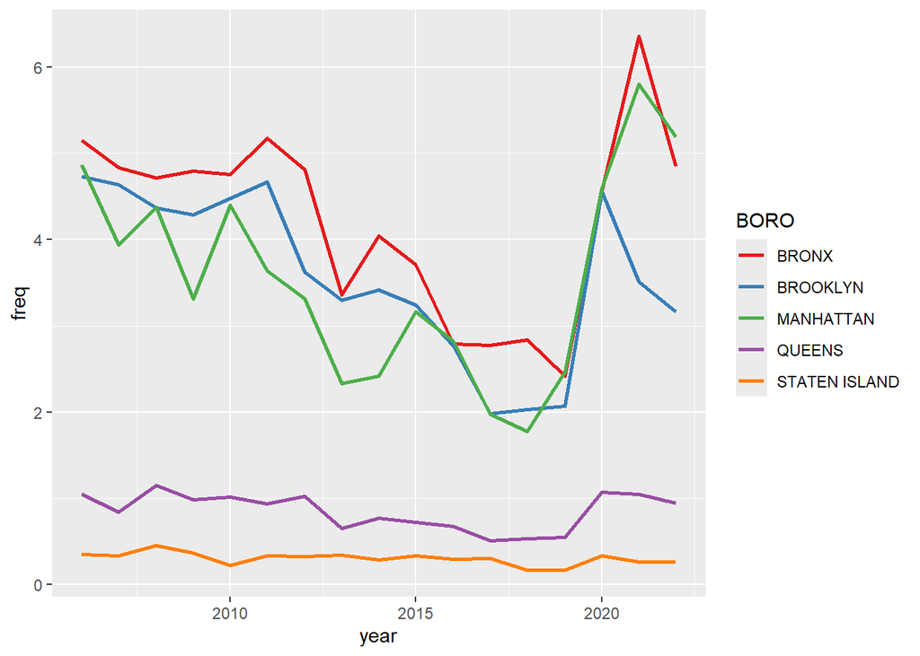

```r
ggplot(distribution) +
  geom_line(aes(x =year, color=BORO, y=freq), size=1)+
  scale_color_brewer(palette='Set1')
```

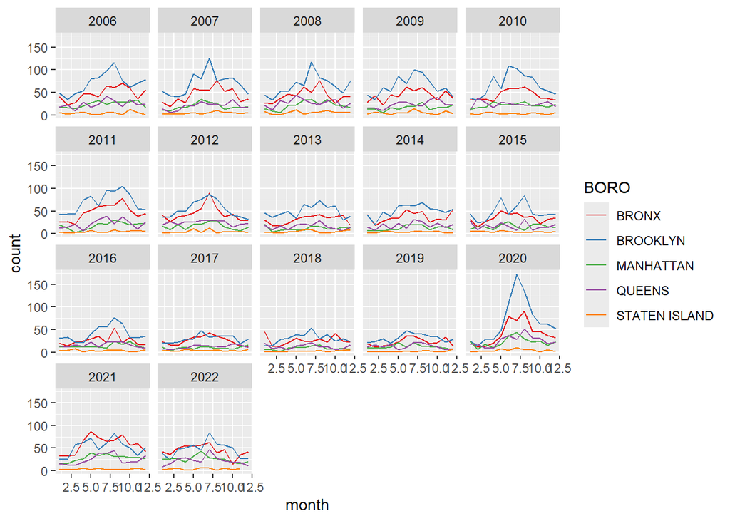

```r
ggplot(data)+
  geom_line(aes(x=month, color=BORO), stat='count') +
  scale_color_brewer(palette='Set1')+
  facet_wrap(~year)
```

Now, let’s explore the distribution of incidents across different hours of the day to identify which hours are considered safer.

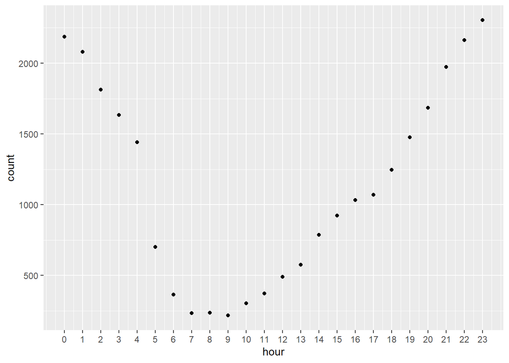

```r
ggplot(data %>% mutate(hour = hour))+
         geom_point(aes(x=hour), stat = 'count')+
  scale_x_continuous(breaks=seq(0,23))
```

We can model this distribution using a third-degree polynomial linear model.

```r
data_h <- data %>% group_by(hour) %>% summarise(N=n())
lm_model <- lm(N~poly(hour, 3), data=data_h)
summary(lm_model)
```

```
##
## Call:
## lm(formula = N ~ poly(hour, 3), data = data_h)
##
## Residuals:
##     Min      1Q  Median      3Q     Max
## -334.32  -73.01  -19.88   59.06  424.64
##
## Coefficients:
##                Estimate Std. Error t value Pr(>|t|)
## (Intercept)     1138.00      37.09  30.684  < 2e-16 ***
## poly(hour, 3)1   582.16     181.69   3.204  0.00445 **
## poly(hour, 3)2  3210.57     181.69  17.670 1.13e-13 ***
## poly(hour, 3)3  -682.47     181.69  -3.756  0.00124 **
## ---
## Signif. codes:  0 '***' 0.001 '**' 0.01 '*' 0.05 '.' 0.1 ' ' 1
##
## Residual standard error: 181.7 on 20 degrees of freedom
## Multiple R-squared:  0.9439, Adjusted R-squared:  0.9355
## F-statistic: 112.2 on 3 and 20 DF,  p-value: 1.109e-12
```

Additionally, we can visualize the residuals on a graph to assess the model’s fit.

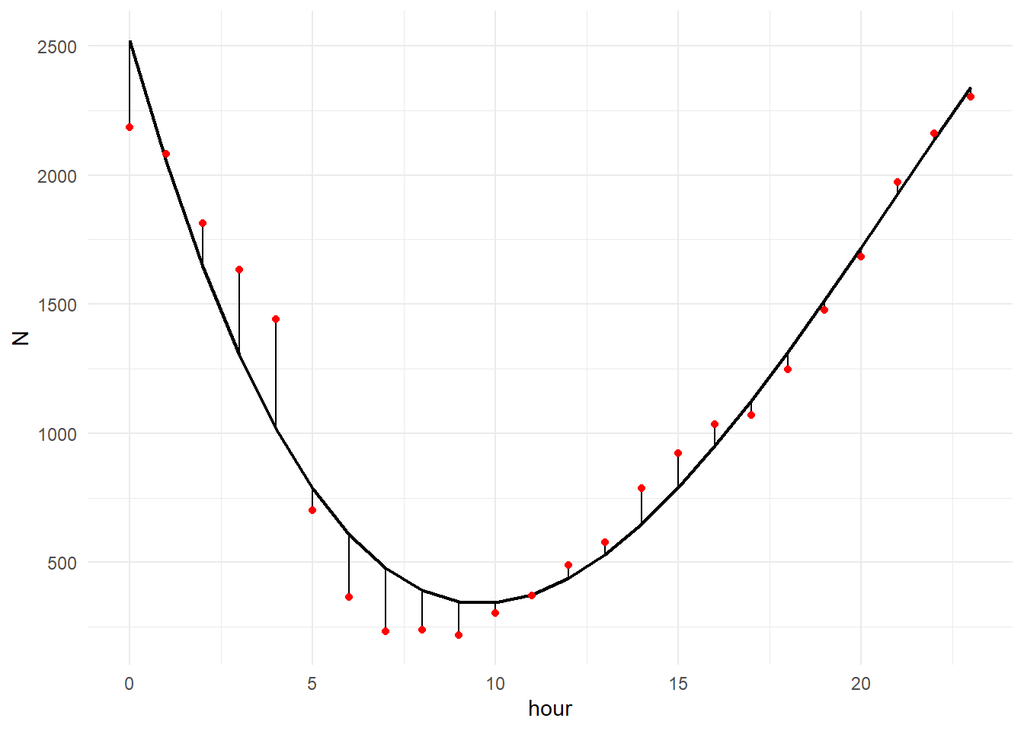

```r
predicted <- predict(lm_model, data_h)

# Residuals (errors)
residuals <- resid(lm_model)

# Combine predicted values and residuals into a data frame
plot_data <- data.frame(hour=data_h$hour, N = data_h$N, y = predicted, residuals = residuals)

# Plot the data points and the fitted curve
ggplot(plot_data, aes(x = hour, y = N)) +
  geom_line(aes(y = y), size=0.8) +  # Fitted curve
  geom_segment(aes(xend = hour, yend = N - residuals)) +  # Error bars
  geom_point(color = "red") +
  theme_minimal()
```

## Conclusion

Through spatial and temporal analysis, we gain valuable insights into the patterns and trends of shooting incidents in New York City. This analysis provides a comprehensive understanding of safety dynamics, which can inform policymakers, law enforcement agencies, and community stakeholders in implementing targeted interventions and strategies to address violence and enhance public safety.  
Anyway, it is essential to acknowledge certain limitations and potential biases inherent in the data and analytical approach. One notable limitation is the reliance on reported incidents, which may be subject to underreporting or misclassification biases. Factors such as disparities in reporting practices across neighborhoods could skew the representation of incident patterns.  
Spatial and temporal analyses may be influenced by factors such as population density, leading to spatial and temporal biases in the data.  
The use of statistical modeling techniques, while informative, may introduce biases based on model specifications.  
It is crucial for readers to interpret the findings with these limitations in mind and consider alternative data sources or methodologies to mitigate biases and ensure a more comprehensive understanding of safety dynamics in the city.